# R workshop @TESRI

2019年1月28日

## 資料匯入、檢視、基礎敘述統計

## 大綱

### 資料讀取

### 檢視資料

### 處理資料

-變數調整

-篩選與清理

## 安裝套件與設定路徑

```r
#安裝所需的套件
library(readxl)
```

```r
#設定路徑
setwd("D:/Desktop/R_tutorial")
getwd()
```

```
## [1] "D:/Desktop/R_tutorial"
```

## 讀入資料

- 讀取xlsx

```r
   #一共有幾個sheet?
   excel_sheets("2018_S1_S4_0.1.xlsx")
```

```
## [1] "S4" "S3" "S2" "S1"
```

```r
   s1 <- read_xlsx("2018_S1_S4_0.1.xlsx", sheet = "S1")
   s2 <- read_xlsx("2018_S1_S4_0.1.xlsx", sheet = "S2")
   s3 <- read_xlsx("2018_S1_S4_0.1.xlsx", sheet = "S3")
   s4 <- read_xlsx("2018_S1_S4_0.1.xlsx", sheet = "S4")
   head(s1)
```

[output not shown]

使用sheet指定工作表

## 讀入資料

- 或讀取 txt csv

```r
 s1 <- read.csv("2018_S1_0.1.csv", header=TRUE , sep="\t" , fileEncoding='big5')

 s2 <- read.table("2018_S2_0.1.txt", header=TRUE , sep="\t")
```

header 是否有欄位頭 ; sep 文字分隔

## 檢視資料

- head() tail() view()

```r
head(s3)
```

```
## # A tibble: 6 x 15
##     fid `Report NO.` Season   `Team No.` `Team Name` Grid_ID `Survey time`
##   <dbl>        <dbl> <chr>         <dbl> <chr>         <dbl> <chr>
## 1     1       147413 2018夏季(~      67551 雲林綠色隧道隊~     731 2018-07-12 0~
## 2     2       150339 2018夏季(~      67783 嘉大兩爬研      850 2018-07-29 0~
## 3     3       146554 2018夏季(~      70663 小編暫時認養，歡迎社~     276 2018-07-02 1~
## 4     4       147738 2018夏季(~     147615 鳥的祖先是恐龍啦~    1105 2018-07-15 1~
## 5     5       148948 2018夏季(~      67557 澱粉萬歲        179 2018-07-18 0~
## 6     6       149947 2018夏季(~     147334 去海邊仙仙隊~      81 2018-07-24 1~
## # ... with 8 more variables: Road_Type <chr>, Vehicle <chr>, `RK
## #   Event` <dbl>, Doggy <dbl>, Kitty <dbl>, `Length (KM)` <dbl>,
## #   Road_Density <chr>, Ecoregion <chr>
```

## 檢視資料

- class() - 檢視物件Object的屬性

```r
 class(s3)
```

```
## [1] "tbl_df"     "tbl"        "data.frame"
```

```r
 class(s1)
```

```
## [1] "data.frame"
```

read_xlsx會儲存為tibble格式

- dim() - 資料的維度

```r
 dim(s3)
```

```
## [1] 42 15
```

## 檢視資料

- Structure str() – 檢視資料細部結構

```r
 str(s3)
```

```
## Classes 'tbl_df', 'tbl' and 'data.frame':    42 obs. of  15 variables:
##  $ fid         : num  1 2 3 4 5 6 7 8 9 10 ...
##  $ Report NO.  : num  147413 150339 146554 147738 148948 ...
##  $ Season      : chr  "2018夏季(七月)系統化路死動物暨遊蕩犬貓數量調查" "2018夏季(七月)系統化路死動物暨遊蕩犬貓數量調查" "2018夏季(七月)系統化路死動物暨遊蕩犬貓數量調查" "2018夏季(七月)系統化路死動物暨遊蕩犬貓數量調查" ...
##  $ Team No.    : num  67551 67783 70663 147615 67557 ...
##  $ Team Name   : chr  "雲林綠色隧道隊" "嘉大兩爬研" "小編暫時認養，歡迎社友接手" "鳥的祖先是恐龍啦" ...
##  $ Grid_ID     : num  731 850 276 1105 179 ...
##  $ Survey time : chr  "2018-07-12 07:00 ~ 2018-07-12 09:00" "2018-07-29 09:20 ~ 2018-07-29 09:50" "2018-07-02 13:33 ~ 2018-07-02 13:47" "2018-07-15 10:39 ~ 2018-07-15 11:00" ...
##  $ Road_Type   : chr  "1w" "3w" "2w" "4w" ...
##  $ Vehicle     : chr  "bike" "scooter" "car" "scooter" ...
##  $ RK Event    : num  2 0 0 1 8 0 2 0 0 4 ...
##  $ Doggy       : num  1 2 0 0 0 0 0 2 0 0 ...
##  $ Kitty       : num  0 0 0 0 0 0 0 0 0 0 ...
##  $ Length (KM) : num  3.79 3.74 6.88 2.57 8.58 ...
##  $ Road_Density: chr  "H" "M" "M" "H" ...
##  $ Ecoregion   : chr  "CW" "SW" "NW" "SW" ...
```

## 檢視資料

- 樞紐分析 `table()` – 檢視單項類別資料概況

```r
 table( s3$Vehicle ) #用 $ 指定變數
```

```
##
##    bike     car scooter    walk
##       1      19      21       1
```

- `summary()` – 單項數值資料敘述統計

```r
 summary( s3$Doggy )
```

```
##    Min. 1st Qu.  Median    Mean 3rd Qu.    Max.
##   0.000   0.000   0.000   0.619   1.000   5.000
```

`max()`, `min()`, `median()`

為了後面步驟方便，統一轉成data.frame格式

```r
   s1 <- read_xlsx("2018_S1_S4_0.1.xlsx", sheet = "S1")
   s2 <- read_xlsx("2018_S1_S4_0.1.xlsx", sheet = "S2")
   s3 <- read_xlsx("2018_S1_S4_0.1.xlsx", sheet = "S3")
   s4 <- read_xlsx("2018_S1_S4_0.1.xlsx", sheet = "S4")

   s1 <- as.data.frame(s1)
   s2 <- as.data.frame(s2)
   s3 <- as.data.frame(s3)
   s4 <- as.data.frame(s4)
```

可以嘗試 ALT + 滑鼠左鍵 向下拖曳

## 合併資料

```r
rk2018 <- rbind(s1,s2,s3,s4)
```

## data.frame操作資料篩選

## Object [ 列 , 欄 ]

## data.frame操作資料篩選

- 類別資料篩選

  eg.交通工具

```r
rk2018_car <- rk2018[ rk2018$Vehicle == "car" , ]
table(rk2018_car$Vehicle)
```

```
##
## car
##  49
```

- 數值資料篩選

  eg.調查努力量

```r
rk2018_2km <- rk2018[ rk2018$`Length (KM)` > 2 ,]
summary(rk2018_2km$`Length (KM)`)
```

```
##    Length     Class      Mode
##       145 character character
```

## 調整變數

- 改變資料格式

```r
summary(rk2018$`Length (KM)`)
```

```
##    Length     Class      Mode
##       163 character character
```

```r
rk2018$`Length (KM)` <- as.numeric(rk2018$`Length (KM)` )
```

## NAs introduced by coercion

## 調整變數

- 改變欄位名稱

```r
colnames(rk2018)[6] <- "survey_time"
```

## 調整變數

- 改變欄位名稱

```r
colnames(rk2018)[colnames(rk2018)== "Team No."] <- "Team_No."
```

- 去除欄位

```r
rk2018[,"Team Name" ] <- NULL
```

```r
colnames(rk2018)
```

```
##  [1] "fid"          "Report NO."   "Season"       "Team_No."
##  [5] "survey_time"  "Survey time"  "Road_Type"    "Vehicle"
##  [9] "RK Event"     "Doggy"        "Kitty"        "Length (KM)"
## [13] "Road_Density" "Ecoregion"
```

## 調整變數

- 更改資料內容

  eg.簡化文字資料

```r
sname<- unique( rk2018$Season )  #去除重複值
sname
```

```
## [1] "2018冬季(一月)系統化路死動物暨遊蕩犬貓數量調查"
## [2] "2018春季(四月)系統化路死動物暨遊蕩犬貓數量調查"
## [3] "2018夏季(七月)系統化路死動物暨遊蕩犬貓數量調查"
## [4] "2018秋季(十月)系統化路死動物暨遊蕩犬貓數量調查"
```

```r
rk2018$season_new <- ""  #創造新的欄位

rk2018[rk2018$Season == sname[1] , "season_new"] <- "s1"
#-----[行的條件------ 邏輯 ------- ,  指定欄 ]--賦值----#
unique(rk2018$season)
```

```
## [1] "s1" ""
```

– 請自行更新其他三季資料，記得善用 [alt]+[左鍵]

## 資料篩選、清理

- 類別資料篩選

  eg.交通工具

```r
rk2018_good <- rk2018[ rk2018$Vehicle %in% c("walk","bike") , ]
table(rk2018_good$Vehicle)
```

```
##
## bike walk
##    3    7
```

- 數值資料篩選

  eg.調查努力量

```r
rk2018_2km <- rk2018[ rk2018$`Length (KM)` > 2 ,]
summary(rk2018_2km$`Length (KM)`)
```

```
##    Min. 1st Qu.  Median    Mean 3rd Qu.    Max.    NA's
##   2.001   3.029   3.658   4.209   4.705  13.900       2
```

## 資料篩選、清理

- 去除NA

```r
dim( rk2018 )
```

```
## [1] 163  15
```

```r
rk2018_clean <- rk2018[ !is.na(rk2018$`Length (KM)`), ]
dim( rk2018_clean )
```

```
## [1] 161  15
```

```r
#或者
#rk2018_clean <- rk2018[ is.na(rk2018$`Length (KM)`) == FALSE , ]
```

## 練習一下

## 各個生態分區(Ecoregion)有調查3km以上樣線的數量

-樞紐分析、篩選、指定變數

## 各個生態分區有調查3km以上樣線的數量

```r
rk2018_3km <- rk2018[rk2018$`Length (KM)`>3,] #篩選
rk2018_3km$Ecoregion                          #指定變數
```

```r
table(rk2018_3km$Ecoregion)                   #樞紐分析
```

```
##
## CW EN ES NE NW SE SW
## 27 10  9 14 19  7 27
```

`table(rk2018[rk2018$`Length (KM)`>3,"Ecoregion"])`

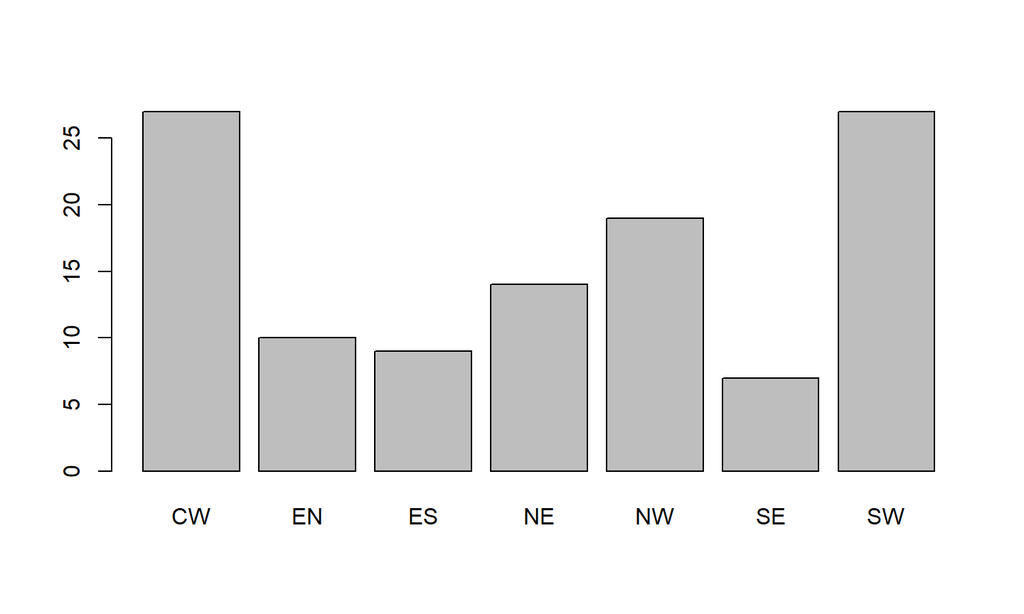

```r
tb <- table(rk2018[rk2018$`Length (KM)`>3,"Ecoregion"])
region.df <- as.data.frame(tb)
colnames(region.df) = c("region","lines")
barplot(region.df$lines,names.arg =region.df$region)
```